# EDA_excersise

New York City Street Tree Census — EDA & Data Cleaning  
Project Overview  
This project demonstrates **Exploratory Data Analysis (EDA)** and **data cleaning** techniques using the **2015 New York City Street Tree Census** dataset. The dataset contains detailed information about street trees across New York City boroughs, including:

- Tree species
- Health condition
- Trunk diameter
- Geographic location
- Sidewalk damage
- Tree-related problems\

Objectives  
The main objectives of this project are:

- Perform Exploratory Data Analysis (EDA)
- Clean and prepare the dataset for analysis
- Identify missing values, inconsistencies, and duplicates
- Explore patterns and relationships within the data
- Create visualizations to better understand tree characteristics and health conditions

Dataset Source  
The dataset can be found here:  
https://data.cityofnewyork.us/Environment/2015-Street-Tree-Census-Tree-Data/uvpi-gqnh/data_preview

STEP0 0: Imports and reading Data

```python
import pandas as pd
import numpy as np
import matplotlib.pylab as plt
import seaborn as sns
plt.style.use('ggplot')

pd.set_option('display.max_columns', 200)
```

```python
df = pd.read_csv('2015_Street_Tree_Census_-_Tree_Data_20260504.csv')
```

Start with the EDA analysis

Step 1: Data understanding  
-Data frame shape  
-Head and tail  
-dtypes  
-describe

```python
df.shape
```

```
(683788, 45)
```

```python
df.head()
```

|  | tree_id | block_id | created_at | tree_dbh | stump_diam | curb_loc | status | health | spc_latin | spc_common | steward | guards | sidewalk | user_type | problems | root_stone | root_grate | root_other | trunk_wire | trnk_light | trnk_other | brch_light | brch_shoe | brch_other | address | postcode | zip_city | community board | borocode | … |
| --- | --- | --- | --- | --- | --- | --- | --- | --- | --- | --- | --- | --- | --- | --- | --- | --- | --- | --- | --- | --- | --- | --- | --- | --- | --- | --- | --- | --- | --- | --- |
| 0 | 180683 | 348711 | 08/27/2015 | 3 | 0 | OnCurb | Alive | Fair | Acer rubrum | red maple | NaN | NaN | NoDamage | TreesCount Staff | NaN | No | No | No | No | No | No | No | No | No | 108-005 70 AVENUE | 11375 | Forest Hills | 406 | 4 | … |
| 1 | 200540 | 315986 | 09/03/2015 | 21 | 0 | OnCurb | Alive | Fair | Quercus palustris | pin oak | NaN | NaN | Damage | TreesCount Staff | Stones | Yes | No | No | No | No | No | No | No | No | 147-074 7 AVENUE | 11357 | Whitestone | 407 | 4 | … |
| 2 | 204026 | 218365 | 09/05/2015 | 3 | 0 | OnCurb | Alive | Good | Gleditsia triacanthos var. inermis | honeylocust | 1or2 | NaN | Damage | Volunteer | NaN | No | No | No | No | No | No | No | No | No | 390 MORGAN AVENUE | 11211 | Brooklyn | 301 | 3 | … |
| 3 | 204337 | 217969 | 09/05/2015 | 10 | 0 | OnCurb | Alive | Good | Gleditsia triacanthos var. inermis | honeylocust | NaN | NaN | Damage | Volunteer | Stones | Yes | No | No | No | No | No | No | No | No | 1027 GRAND STREET | 11211 | Brooklyn | 301 | 3 | … |
| 4 | 189565 | 223043 | 08/30/2015 | 21 | 0 | OnCurb | Alive | Good | Tilia americana | American linden | NaN | NaN | Damage | Volunteer | Stones | Yes | No | No | No | No | No | No | No | No | 603 6 STREET | 11215 | Brooklyn | 306 | 3 | … |

```python
df.columns
```

```
Index(['tree_id', 'block_id', 'created_at', 'tree_dbh', 'stump_diam',
       'curb_loc', 'status', 'health', 'spc_latin', 'spc_common', 'steward',
       'guards', 'sidewalk', 'user_type', 'problems', 'root_stone',
       'root_grate', 'root_other', 'trunk_wire', 'trnk_light', 'trnk_other',
       'brch_light', 'brch_shoe', 'brch_other', 'address', 'postcode',
       'zip_city', 'community board', 'borocode', 'borough', 'cncldist',
       'st_assem', 'st_senate', 'nta', 'nta_name', 'boro_ct', 'state',
       'latitude', 'longitude', 'x_sp', 'y_sp', 'council district',
       'census tract', 'bin', 'bbl'],
      dtype='str')
```

```python
print(df['borough'].value_counts())
```

```
borough
Queens           250551
Brooklyn         177293
Staten Island    105318
Bronx             85203
Manhattan         65423
Name: count, dtype: int64
```

```python
# Check if column tree_id is unique

print(df['tree_id'].is_unique)
```

```
True
```

```python
# Print the possible values of column 'status'

print(df['status'].value_counts())
print(len(df[df['status'] != 'Alive']))
```

```
status
Alive    652173
Stump     17654
Dead      13961
Name: count, dtype: int64
31615
```

```python
df.dtypes
```

```
tree_id               int64
block_id              int64
created_at              str
tree_dbh              int64
stump_diam            int64
curb_loc                str
status                  str
health                  str
spc_latin               str
spc_common              str
steward                 str
guards                  str
sidewalk                str
user_type               str
problems                str
root_stone              str
root_grate              str
root_other              str
trunk_wire              str
trnk_light              str
trnk_other              str
brch_light              str
brch_shoe               str
brch_other              str
address                 str
postcode              int64
zip_city                str
community board       int64
borocode              int64
borough                 str
cncldist              int64
st_assem              int64
st_senate             int64
nta                     str
nta_name                str
boro_ct                 str
state                   str
latitude                str
longitude               str
x_sp                    str
y_sp                    str
council district    float64
census tract            str
bin                 float64
bbl                 float64
dtype: object
```

Latitud and longitud are type str and they should be changed to numeric

```python
#  Check for duplicates

print(df.duplicated().sum())
print(df[df.duplicated()])
```

```
0
Empty DataFrame
Columns: [tree_id, block_id, created_at, tree_dbh, stump_diam, curb_loc, status, health, spc_latin, spc_common, steward, guards, sidewalk, user_type, problems, root_stone, root_grate, root_other, trunk_wire, trnk_light, trnk_other, brch_light, brch_shoe, brch_other, address, postcode, zip_city, comm…
Index: []
```

```python
# Check if there are duplicated in coordinates

print(
    df.duplicated(
        subset=['latitude','longitude', 'spc_common']
    ).sum()
)
```

```
279
```

```python
df[df.duplicated(
    subset=['latitude', 'longitude', 'spc_common'],
    keep=False  # all the rows involved
)].sort_values(['latitude','longitude'])
```

|  | tree_id | block_id | created_at | tree_dbh | stump_diam | curb_loc | status | health | spc_latin | spc_common | steward | guards | sidewalk | user_type | problems | root_stone | root_grate | root_other | trunk_wire | trnk_light | trnk_other | brch_light | brch_shoe | brch_other | address | postcode | zip_city | community board | borocode | … |
| --- | --- | --- | --- | --- | --- | --- | --- | --- | --- | --- | --- | --- | --- | --- | --- | --- | --- | --- | --- | --- | --- | --- | --- | --- | --- | --- | --- | --- | --- | --- |
| 185927 | 387550 | 412396 | 10/27/2015 | 11 | 0 | OffsetFromCurb | Alive | Fair | Liquidambar styraciflua | sweetgum | NaN | NaN | NoDamage | TreesCount Staff | NaN | No | No | No | No | No | No | No | No | No | 6 WAIMER PLACE | 10312 | Staten Island | 503 | 5 | … |
| 186126 | 387551 | 412396 | 10/27/2015 | 8 | 0 | OffsetFromCurb | Alive | Good | Liquidambar styraciflua | sweetgum | NaN | NaN | NoDamage | TreesCount Staff | NaN | No | No | No | No | No | No | No | No | No | 6 WAIMER PLACE | 10312 | Staten Island | 503 | 5 | … |
| 210453 | 397365 | 412431 | 10/29/2015 | 11 | 0 | OnCurb | Alive | Good | Pyrus calleryana | Callery pear | NaN | NaN | Damage | TreesCount Staff | NaN | No | No | No | No | No | No | No | No | No | 511 SINCLAIR AVENUE | 10312 | Staten Island | 503 | 5 | … |
| 212506 | 397366 | 412431 | 10/29/2015 | 14 | 0 | OnCurb | Alive | Good | Pyrus calleryana | Callery pear | NaN | NaN | NoDamage | TreesCount Staff | NaN | No | No | No | No | No | No | No | No | No | 511 SINCLAIR AVENUE | 10312 | Staten Island | 503 | 5 | … |
| 547609 | 57054 | 413850 | 07/09/2015 | 9 | 0 | OnCurb | Alive | Good | Liquidambar styraciflua | sweetgum | NaN | NaN | NoDamage | TreesCount Staff | NaN | No | No | No | No | No | No | No | No | No | 129 SYCAMORE STREET | 10308 | Staten Island | 503 | 5 | … |
| ... | ... | ... | ... | ... | ... | ... | ... | ... | ... | ... | ... | ... | ... | ... | ... | ... | ... | ... | ... | ... | ... | ... | ... | ... | ... | ... | ... | ... | ... | … |
| 279261 | 487771 | 601050 | 11/29/2015 | 2 | 0 | OffsetFromCurb | Alive | Good | Fraxinus | ash | 1or2 | NaN | NoDamage | Volunteer | NaN | No | No | No | No | No | No | No | No | No | 171 WEST 236 STREET | 10463 | Bronx | 208 | 2 | … |
| 281239 | 487769 | 601050 | 11/29/2015 | 2 | 0 | OffsetFromCurb | Alive | Good | Fraxinus | ash | 1or2 | NaN | NoDamage | Volunteer | NaN | No | No | No | No | No | No | No | No | No | 171 WEST 236 STREET | 10463 | Bronx | 208 | 2 | … |
| 283983 | 487768 | 601050 | 11/29/2015 | 2 | 0 | OffsetFromCurb | Alive | Good | Fraxinus | ash | 1or2 | NaN | NoDamage | Volunteer | NaN | No | No | No | No | No | No | No | No | No | 171 WEST 236 STREET | 10463 | Bronx | 208 | 2 | … |
| 283984 | 487770 | 601050 | 11/29/2015 | 3 | 0 | OffsetFromCurb | Alive | Good | Fraxinus | ash | 1or2 | NaN | NoDamage | Volunteer | NaN | No | No | No | No | No | No | No | No | No | 171 WEST 236 STREET | 10463 | Bronx | 208 | 2 | … |
| 284395 | 487773 | 601050 | 11/29/2015 | 3 | 0 | OffsetFromCurb | Alive | Good | Fraxinus | ash | 1or2 | NaN | NoDamage | Volunteer | NaN | No | No | No | No | No | No | No | No | No | 171 WEST 236 STREET | 10463 | Bronx | 208 | 2 | … |

417 rows × 45 columns

There are repeated coordinates, it migth be that multiple trees from the same species are planted very close

Lets see the percent of null values in every column

```python
df.isnull().sum() *100/len(df)
```

```
tree_id              0.000000
block_id             0.000000
created_at           0.000000
tree_dbh             0.000000
stump_diam           0.000000
curb_loc             0.000000
status               0.000000
health               4.623655
spc_latin            4.624094
spc_common           4.624094
steward             75.964773
guards              88.320064
sidewalk             4.623655
user_type            0.000000
problems            66.971634
root_stone           0.000000
root_grate           0.000000
root_other           0.000000
trunk_wire           0.000000
trnk_light           0.000000
trnk_other           0.000000
brch_light           0.000000
brch_shoe            0.000000
brch_other           0.000000
address              0.000000
postcode             0.000000
zip_city             0.000000
community board      0.000000
borocode             0.000000
borough              0.000000
cncldist             0.000000
st_assem             0.000000
st_senate            0.000000
nta                  0.000000
nta_name             0.000000
boro_ct              0.000000
state                0.000000
latitude             0.000000
longitude            0.000000
x_sp                 0.000000
y_sp                 0.000000
council district     0.953366
census tract         0.953366
bin                  1.397948
bbl                  1.397948
dtype: float64
```

```python
# 'health', 'spc_latin', 'spc_common' and 'sidewalk'  have almost the same percent of nulls: 4.6% , there must be a relationship on those columns.

print(df['health'].isna().sum())
print(df['sidewalk'].isna().sum())
print(df['spc_common'].isna().sum())
print(df['spc_latin'].isna().sum())
```

```
31616
31616
31619
31619
```

```python
# Pri
print("Alive:")
print("health  sidewalk  spc_common  spc_latin")
print(
        df[df['status'] == 'Alive'] ['health'].isna().sum(), "      ",
        df[df['status'] == 'Alive'] ['sidewalk'].isna().sum(),"       ",
        df[df['status'] == 'Alive'] ['spc_common'].isna().sum(),"         ",
        df[df['status'] == 'Alive'] ['spc_latin'].isna().sum()
)



print("Dead/Stump:")
print("health  sidewalk  spc_common  spc_latin")
print(
       df[df['status'].isin(['Stump', 'Dead'])]['health'].isna().sum(),"  ",
       df[df['status'].isin(['Stump', 'Dead'])]['sidewalk'].isna().sum(),"   ",
       df[df['status'].isin(['Stump', 'Dead'])]['spc_common'].isna().sum(),"    ",
       df[df['status'].isin(['Stump', 'Dead'])]['spc_latin'].isna().sum()
)
```

```
Alive:
health  sidewalk  spc_common  spc_latin
1        1         5           5
Dead/Stump:
health  sidewalk  spc_common  spc_latin
31615    31615     31614      31614
```

The majority of nulls values in the columns 'health', 'spc_latin', 'spc_common' and 'sidewalk' is when the status of the tree is Dead or Stump.

```python
# This will print the rows where health is null and status is different than 'Stump' and 'dead'

print("Health \n", df[(df['health'].isna()) & (~df['status'].isin(['Stump','Dead']))] [['health','status', 'sidewalk','spc_common','spc_latin']])
print("sidewalk \n", df[(df['sidewalk'].isna()) & (~df['status'].isin(['Stump','Dead']))] [['health','status', 'sidewalk','spc_common','spc_latin']])
print("spc_common \n", df[(df['spc_common'].isna()) & (~df['status'].isin(['Stump','Dead']))] [['health','status', 'sidewalk','spc_common','spc_latin']])
print("spc_latin \n", df[(df['spc_latin'].isna()) & (~df['status'].isin(['Stump','Dead']))] [['health','status', 'sidewalk','spc_common','spc_latin']])
```

```
Health
       health status sidewalk spc_common               spc_latin
32889    NaN  Alive   Damage  green ash  Fraxinus pennsylvanica
sidewalk
        health status sidewalk   spc_common                           spc_latin
346299   Good  Alive      NaN  honeylocust  Gleditsia triacanthos var. inermis
spc_common
        health status  sidewalk spc_common spc_latin
356613   Good  Alive  NoDamage        NaN       NaN
427541   Poor  Alive    Damage        NaN       NaN
431417   Good  Alive    Damage        NaN       NaN
608632   Good  Alive  NoDamage        NaN       NaN
656960   Good  Alive    Damage        NaN       NaN
spc_latin
        health status  sidewalk spc_common spc_latin
356613   Good  Alive  NoDamage        NaN       NaN
427541   Poor  Alive    Damage        NaN       NaN
431417   Good  Alive    Damage        NaN       NaN
608632   Good  Alive  NoDamage        NaN       NaN
656960   Good  Alive    Damage        NaN       NaN
```

We are going to work only with tree in status alive. There are still NaN values for those columns when status is Alive, but there are only 7 rows that can be easily removed.

```python
# Now let's check the column 'problems' wichs shows about 67% of nulls

print(df['problems'].isna().sum())
```

```
457944
```

```python
# It is suspected that column problems has a null value when the columns below
# are all of them equal to 'No', the following code is written to prove that
# theory.

problems_cols = ['root_stone','root_grate', 'root_other','trunk_wire',
                'trnk_light','trnk_other', 'brch_light', 'brch_shoe',
                'brch_other']

df['has_a_problem'] = df[problems_cols].eq('Yes').any(axis=1)

print(df['has_a_problem'].value_counts())

df[(df['has_a_problem']) & (df['problems'].isna())]
```

```
has_a_problem
False    457944
True     225844
Name: count, dtype: int64
```

|  | tree_id | block_id | created_at | tree_dbh | stump_diam | curb_loc | status | health | spc_latin | spc_common | steward | guards | sidewalk | user_type | problems | root_stone | root_grate | root_other | trunk_wire | trnk_light | trnk_other | brch_light | brch_shoe | brch_other | address | postcode | zip_city | community board | borocode | … |
| --- | --- | --- | --- | --- | --- | --- | --- | --- | --- | --- | --- | --- | --- | --- | --- | --- | --- | --- | --- | --- | --- | --- | --- | --- | --- | --- | --- | --- | --- | --- |

No rows are printed. This confirms the fact that the nulls in problems is when all the columns above 'root_stone','root_grate', 'root_other','trunk_wire', 'trnk_light','trnk_other', 'brch_light', 'brch_shoe', 'brch_other' are equal to No  
We can replace the values null of problems with the text: "No problems"

```python
df['zip_city'].value_counts()
```

```
zip_city
Brooklyn               177300
Staten Island          105318
Bronx                   85203
New York                64488
Jamaica                 26028
Flushing                23389
Ridgewood               10937
Fresh Meadows           10441
Queens Village          10127
Astoria                 10007
Whitestone               9449
Bayside                  8679
Springfield Gardens      7470
Little Neck              7280
Forest Hills             7059
Oakland Gardens          7054
Far Rockaway             6887
East Elmhurst            6475
Rosedale                 6324
Woodside                 5651
South Ozone Park         5494
Ozone Park               5456
Bellerose                5121
Middle Village           4893
Saint Albans             4697
Howard Beach             4650
Corona                   4346
Elmhurst                 4204
Glen Oaks                4130
Maspeth                  4033
Hollis                   3591
Rockaway Park            3572
Long Island City         3479
Richmond Hill            3391
Jackson Heights          3295
Cambria Heights          3229
College Point            3099
Rego Park                3084
Woodhaven                2855
South Richmond Hill      2805
Arverne                  2013
Kew Gardens              1743
Sunnyside                1664
Floral Park              1539
Central Park              935
New Hyde Park             865
Breezy Point               30
Inwood                      9
Name: count, dtype: int64
```

```python
print(df[df['zip_city'] == 'Brooklyn'] [['zip_city', 'postcode']])
```

```
        zip_city  postcode
2       Brooklyn     11211
3       Brooklyn     11211
4       Brooklyn     11215
9       Brooklyn     11223
13      Brooklyn     11205
...          ...       ...
683777  Brooklyn     11213
683778  Brooklyn     11230
683779  Brooklyn     11229
683781  Brooklyn     11226
683783  Brooklyn     11211

[177300 rows x 2 columns]
```

One Zip_city could have sveral postcodes

```python
# Insert a new column that will contain the diameter of the tree trunk in centimeters

# Coversion from inches to centimeters
df['tree_dbh_cm'] = df['tree_dbh'] * 2.54

# Since the new column is inserted at the end, the following procedure will move the last column and put it after to the tree_dbh column

cols = list(df.columns)

cols.remove('tree_dbh_cm')

idx = cols.index('tree_dbh')

cols.insert(idx + 1,'tree_dbh_cm')

df = df[cols]

df.head()
```

|  | tree_id | block_id | created_at | tree_dbh | tree_dbh_cm | stump_diam | curb_loc | status | health | spc_latin | spc_common | steward | guards | sidewalk | user_type | problems | root_stone | root_grate | root_other | trunk_wire | trnk_light | trnk_other | brch_light | brch_shoe | brch_other | address | postcode | zip_city | community board | … |
| --- | --- | --- | --- | --- | --- | --- | --- | --- | --- | --- | --- | --- | --- | --- | --- | --- | --- | --- | --- | --- | --- | --- | --- | --- | --- | --- | --- | --- | --- | --- |
| 0 | 180683 | 348711 | 08/27/2015 | 3 | 7.62 | 0 | OnCurb | Alive | Fair | Acer rubrum | red maple | NaN | NaN | NoDamage | TreesCount Staff | NaN | No | No | No | No | No | No | No | No | No | 108-005 70 AVENUE | 11375 | Forest Hills | 406 | … |
| 1 | 200540 | 315986 | 09/03/2015 | 21 | 53.34 | 0 | OnCurb | Alive | Fair | Quercus palustris | pin oak | NaN | NaN | Damage | TreesCount Staff | Stones | Yes | No | No | No | No | No | No | No | No | 147-074 7 AVENUE | 11357 | Whitestone | 407 | … |
| 2 | 204026 | 218365 | 09/05/2015 | 3 | 7.62 | 0 | OnCurb | Alive | Good | Gleditsia triacanthos var. inermis | honeylocust | 1or2 | NaN | Damage | Volunteer | NaN | No | No | No | No | No | No | No | No | No | 390 MORGAN AVENUE | 11211 | Brooklyn | 301 | … |
| 3 | 204337 | 217969 | 09/05/2015 | 10 | 25.40 | 0 | OnCurb | Alive | Good | Gleditsia triacanthos var. inermis | honeylocust | NaN | NaN | Damage | Volunteer | Stones | Yes | No | No | No | No | No | No | No | No | 1027 GRAND STREET | 11211 | Brooklyn | 301 | … |
| 4 | 189565 | 223043 | 08/30/2015 | 21 | 53.34 | 0 | OnCurb | Alive | Good | Tilia americana | American linden | NaN | NaN | Damage | Volunteer | Stones | Yes | No | No | No | No | No | No | No | No | 603 6 STREET | 11215 | Brooklyn | 306 | … |

```python
print(df['state'].value_counts())
```

```
state
New York    683788
Name: count, dtype: int64
```

```python
df.describe()
```

|  | tree_id | block_id | tree_dbh | tree_dbh_cm | stump_diam | postcode | community board | borocode | cncldist | st_assem | st_senate | council district | bin | bbl |
| --- | --- | --- | --- | --- | --- | --- | --- | --- | --- | --- | --- | --- | --- | --- |
| count | 683788.000000 | 683788.000000 | 683788.000000 | 683788.000000 | 683788.000000 | 683788.000000 | 683788.000000 | 683788.000000 | 683788.000000 | 683788.000000 | 683788.000000 | 677269.000000 | 6.742290e+05 | 6.742290e+05 |
| mean | 365205.011085 | 313793.096236 | 11.279787 | 28.650659 | 0.432463 | 10916.246044 | 343.505404 | 3.358500 | 29.943181 | 50.791583 | 20.615781 | 30.027330 | 3.495439e+06 | 3.413414e+09 |
| std | 208122.092902 | 114839.024312 | 8.723042 | 22.156527 | 3.290241 | 651.553364 | 115.740601 | 1.166746 | 14.328531 | 18.966520 | 7.390844 | 14.301717 | 1.193275e+06 | 1.174892e+09 |
| min | 3.000000 | 100002.000000 | 0.000000 | 0.000000 | 0.000000 | 83.000000 | 101.000000 | 1.000000 | 1.000000 | 23.000000 | 10.000000 | 1.000000 | 1.000000e+06 | 0.000000e+00 |
| 25% | 186582.750000 | 221556.000000 | 4.000000 | 10.160000 | 0.000000 | 10451.000000 | 302.000000 | 3.000000 | 19.000000 | 33.000000 | 14.000000 | 19.000000 | 3.031991e+06 | 3.011240e+09 |
| 50% | 366214.500000 | 319967.000000 | 9.000000 | 22.860000 | 0.000000 | 11214.000000 | 402.000000 | 4.000000 | 30.000000 | 52.000000 | 21.000000 | 30.000000 | 4.020352e+06 | 4.008560e+09 |
| 75% | 546170.250000 | 404624.000000 | 16.000000 | 40.640000 | 0.000000 | 11365.000000 | 412.000000 | 4.000000 | 43.000000 | 64.000000 | 25.000000 | 43.000000 | 4.263123e+06 | 4.105700e+09 |
| max | 722694.000000 | 999999.000000 | 450.000000 | 1143.000000 | 140.000000 | 11697.000000 | 503.000000 | 5.000000 | 51.000000 | 87.000000 | 36.000000 | 51.000000 | 5.515124e+06 | 5.080500e+09 |

## Cleaning

```python
# First we will fix the NaN values of the columns "problems"

condition = df[problems_cols].eq('No').all(axis=1)
df.loc[condition & df['problems'].isna(), 'problems'] = 'No problems'
```

```python
# Convert the column of corrdinates from str to numeric.

df['latitude'] = df['latitude'].str.replace(',','.',regex=False)
df['longitude'] = df['longitude'].str.replace(',','.',regex=False)

df['latitude'] = pd.to_numeric(df['latitude'], errors='coerce')
df['longitude'] = pd.to_numeric(df['longitude'], errors ='coerce')
```

```python
#  Remove the rows with values null for the columns: 'health', 'spc_latin', 'spc_common' and 'sidewalk' where status = 'Alive'

rows_to_remove = [32889, 346299, 356613, 427541, 431417, 608632, 656960]

df = df.drop(index=rows_to_remove)
```

```python
# We will work only with Trees in status "Alive"

df_clean = df[df['status'] == 'Alive']
```

```python
print(df_clean.shape)
print(df_clean.columns)
```

```
(652166, 47)
Index(['tree_id', 'block_id', 'created_at', 'tree_dbh', 'tree_dbh_cm',
       'stump_diam', 'curb_loc', 'status', 'health', 'spc_latin', 'spc_common',
       'steward', 'guards', 'sidewalk', 'user_type', 'problems', 'root_stone',
       'root_grate', 'root_other', 'trunk_wire', 'trnk_light', 'trnk_other',
       'brch_light', 'brch_shoe', 'brch_other', 'address', 'postcode',
       'zip_city', 'community board', 'borocode', 'borough', 'cncldist',
       'st_assem', 'st_senate', 'nta', 'nta_name', 'boro_ct', 'state',
       'latitude', 'longitude', 'x_sp', 'y_sp', 'council district',
       'census tract', 'bin', 'bbl', 'has_a_problem'],
      dtype='str')
```

```python
# I will select the columns more important

columns_to_keep = [
    'tree_id',
    'tree_dbh_cm',
    'health',
    'spc_latin',
    'spc_common',
    'sidewalk',
    'user_type',
    'problems',
    'postcode',
    'borough',
    'latitude',
    'longitude'
]

df_clean = df_clean[columns_to_keep]
```

```python
df_clean.head()
```

|  | tree_id | tree_dbh_cm | health | spc_latin | spc_common | sidewalk | user_type | problems | postcode | borough | latitude | longitude |
| --- | --- | --- | --- | --- | --- | --- | --- | --- | --- | --- | --- | --- |
| 0 | 180683 | 7.62 | Fair | Acer rubrum | red maple | NoDamage | TreesCount Staff | No problems | 11375 | Queens | 40.723092 | -73.844215 |
| 1 | 200540 | 53.34 | Fair | Quercus palustris | pin oak | Damage | TreesCount Staff | Stones | 11357 | Queens | 40.794111 | -73.818679 |
| 2 | 204026 | 7.62 | Good | Gleditsia triacanthos var. inermis | honeylocust | Damage | Volunteer | No problems | 11211 | Brooklyn | 40.717581 | -73.936608 |
| 3 | 204337 | 25.40 | Good | Gleditsia triacanthos var. inermis | honeylocust | Damage | Volunteer | Stones | 11211 | Brooklyn | 40.713537 | -73.934456 |
| 4 | 189565 | 53.34 | Good | Tilia americana | American linden | Damage | Volunteer | Stones | 11215 | Brooklyn | 40.666778 | -73.975979 |

```python
# Check for null values

df_clean.isnull().sum() *100/len(df)
```

```
tree_id        0.0
tree_dbh_cm    0.0
health         0.0
spc_latin      0.0
spc_common     0.0
sidewalk       0.0
user_type      0.0
problems       0.0
postcode       0.0
borough        0.0
latitude       0.0
longitude      0.0
dtype: float64
```

```python
df_clean.dtypes
```

```
tree_id          int64
tree_dbh_cm    float64
health             str
spc_latin          str
spc_common         str
sidewalk           str
user_type          str
problems           str
postcode         int64
borough            str
latitude       float64
longitude      float64
dtype: object
```

## Visualization

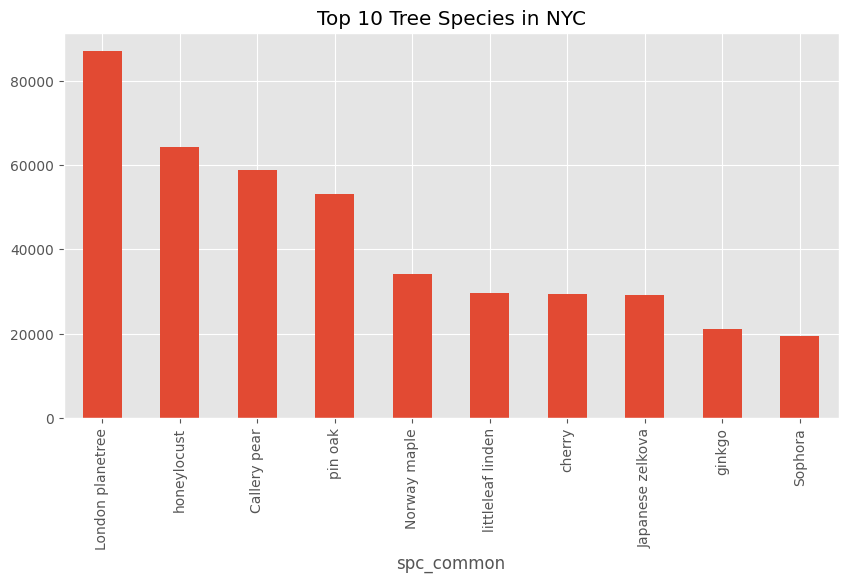

```python
# Let's see the top 10 Species
#
df_clean['spc_common'].value_counts().head(10).plot(
    kind='bar',
    figsize=(10,5),
    title='Top 10 Tree Species in NYC'
)
```

```python
health_species = pd.crosstab(df_clean['spc_common'],df_clean['health'])

print(health_species)
```

```
health                  Fair  Good  Poor
spc_common
'Schubert' chokecherry   717  3929   242
American beech            38   214    21
American elm            1295  6412   268
American hophornbeam     158   866    57
American hornbeam        203  1221    93
...                      ...   ...   ...
weeping willow            51   218    13
white ash                166   897    58
white oak                263  1331    92
white pine                36   155    11
willow oak               360  2725    99

[132 rows x 3 columns]
```

```python
health_species['Good_pct'] = (

    health_species['Good'] / health_species.sum(axis=1)

) * 100

print(health_species)
```

```
health                  Fair  Good  Poor   Good_pct
spc_common
'Schubert' chokecherry   717  3929   242  80.380524
American beech            38   214    21  78.388278
American elm            1295  6412   268  80.401254
American hophornbeam     158   866    57  80.111008
American hornbeam        203  1221    93  80.487805
...                      ...   ...   ...        ...
weeping willow            51   218    13  77.304965
white ash                166   897    58  80.017841
white oak                263  1331    92  78.944247
white pine                36   155    11  76.732673
willow oak               360  2725    99  85.584171

[132 rows x 4 columns]
```

```python
health_species = health_species.sort_values('Good_pct', ascending=False)

print(health_species)
```

```
health          Fair   Good  Poor    Good_pct
spc_common
pitch pine         0     33     0  100.000000
arborvitae        17    305     6   92.987805
false cypress      9     97     2   89.814815
Osage-orange       3     26     0   89.655172
red pine          10     95     1   89.622642
...              ...    ...   ...         ...
Amur cork tree    38    121    24   66.120219
pond cypress      36    117    28   64.640884
katsura tree     220    581   110   63.776070
Norway maple    9162  21248  3779   62.148644
black pine        16     18     3   48.648649

[132 rows x 4 columns]
```

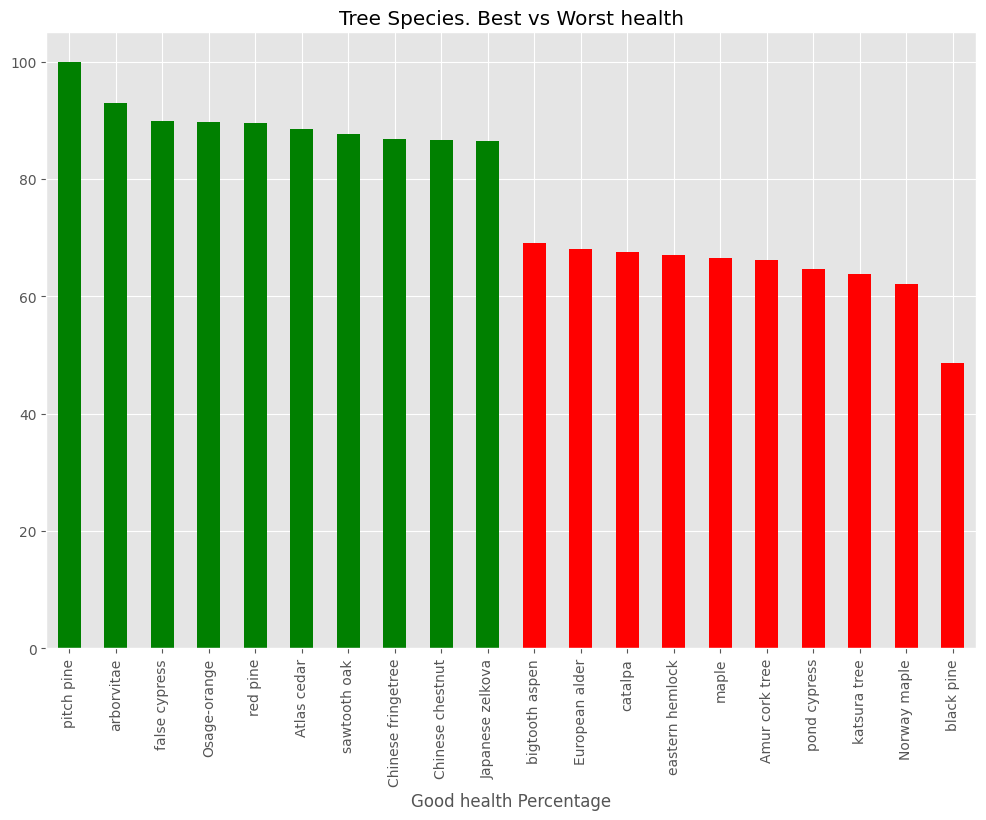

```python
best = health_species['Good_pct'].head(10)
worst = health_species['Good_pct'].tail(10)

combined = pd.concat([best, worst])

colors = (
    ['green'] * len(best) +
    ['red'] * len(best)
)

combined.plot(
    kind='bar',
    figsize=(12,8),
    color = colors,
    title ='Tree Species. Best vs Worst health',
    xlabel = 'Good health Percentage'
)
```

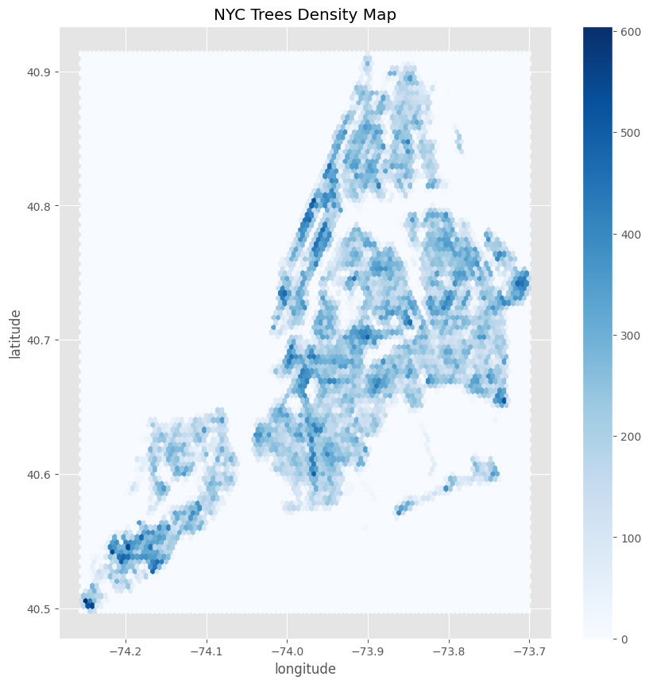

```python
df_clean.plot(
    kind='hexbin',
    x='longitude',
    y='latitude',
    gridsize=100,
    cmap='Blues',
    figsize=(10,10),
    title='NYC Trees Density Map'
)
```

```python
health_colors = {
    'Good' : 'green',
    'Fair': 'orange',
    'Poor':'red'
}
```

```python
df_clean.shape
```

```
(652166, 12)
```

```python
# Filtering some rows will help to visibility, like simulating a zoom

df_filter = df_clean[
    (df_clean['latitude'] > 40.5) &
    (df_clean['latitude'] < 41) &
    (df_clean['longitude'] > -74.5) &
    (df_clean['longitude'] < -73.5)
]
```

```python
df_filter.shape
```

```
(651951, 12)
```

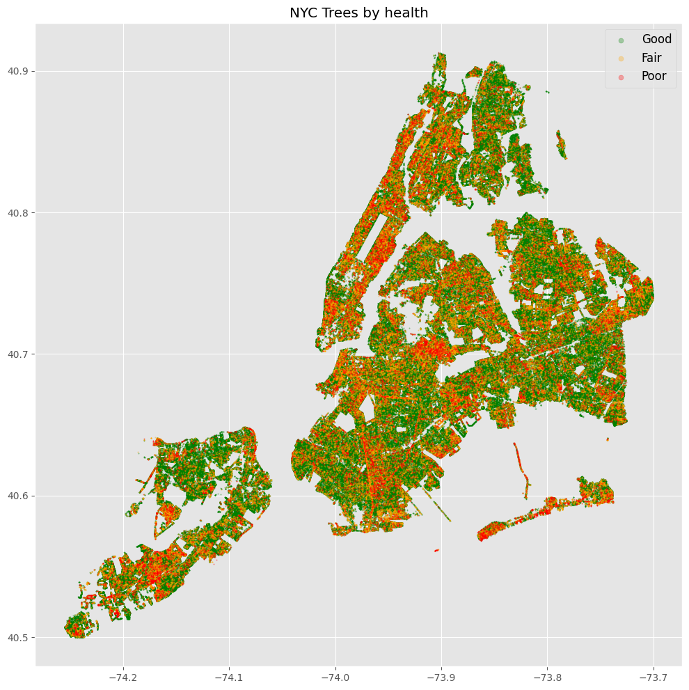

```python
plt.figure(figsize=(12,12))

for h, color in health_colors.items():
    subset = df_filter[df_filter['health'] == h]
    plt.scatter(
        subset['longitude'],
        subset['latitude'],
        c=color,
        s=1,
        alpha=0.3,
        label=h
    )

plt.legend(fontsize=12,markerscale=5)
plt.title('NYC Trees by health')
plt.show()
```

```python
Borough_health = pd.crosstab(
    df_clean['borough'],
    df_clean['health'],
    normalize='index'
) * 100
```

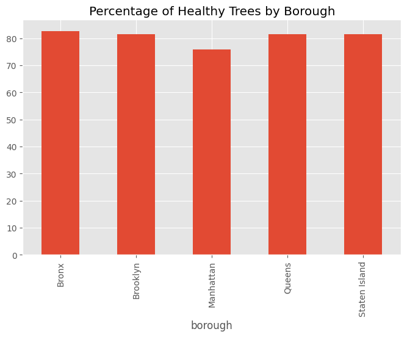

```python
Borough_health['Good'].plot(
    kind='bar',
    figsize=(8,5),
    title='Percentage of Healthy Trees by Borough'
)
```

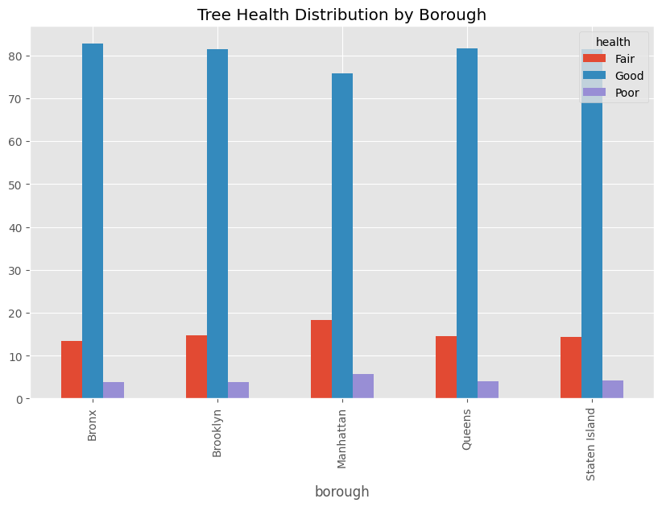

```python
Borough_health.plot(
    kind='bar',
    figsize=(10,6),
    title='Tree Health Distribution by Borough'
)
```

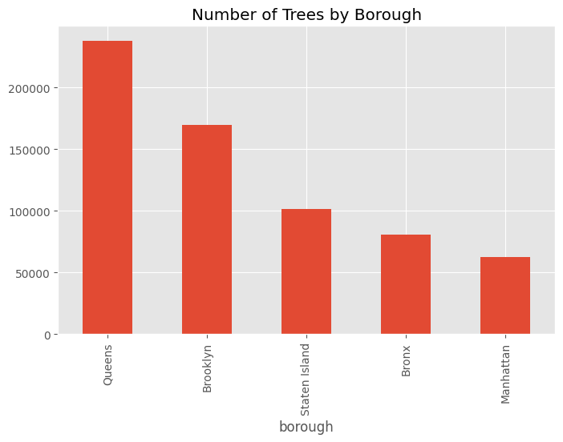

```python
df_clean['borough'].value_counts().plot(
    kind='bar',
    figsize=(8,5),
    title='Number of Trees by Borough'
)
```

```python
density = pd.DataFrame({
    'borough':[
        'Brooklyn',
        'Manhattan',
        'Queens',
        'Staten Island',
        'Bronx'
    ],
    'density': [
        15227,
        28872,
        8542,
        3327,
        13482
    ]
})
```

```python
poor_pct = (
    pd.crosstab(df_clean['borough'], df_clean['health'],
                normalize='index') * 100
) ['Poor'].reset_index()
```

```python
borough_analysis = density.merge(
    poor_pct,
    on = 'borough'
)
```

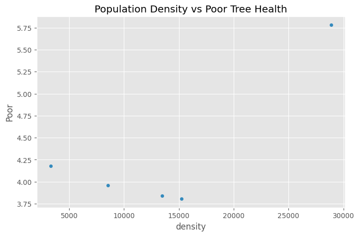

```python
borough_analysis.plot (
    kind = 'scatter',
    x = 'density',
    y = 'Poor',
    figsize=(8,5),
    title='Population Density vs Poor Tree Health'
)
```